# Tugas Unsupervised Learning

Dinda Dwi Anugrah Pertiwi

2026-03-31

# FUZZY CLUSTERING

## Pendahuluan

*Fuzzy Clustering* merupakan suatu metode clustering yang hampir mirip seperti k-means clustering. Karena metode clustering ini mirip dengan k-means clustering, ada yang menyebut metode ini fuzzy k-means clustering. Fuzzy c-means merupakan salah satu jenis soft clustering dimana dalam mengelompokan suatu data, setiap data bisa dimiliki lebih dari satu cluster. Contohnya sebuah tomat bisa dikelompokkan ke warna merah *atau* warna hijau jika dalam hard clustering, namun tomat bisa dikelompokkan ke warna merah *dan* hijau dalam fuzzy clustering.

- Menggunakan skor keanggotaan antara 0 dan 1 (misalkan dengan angka dari 0 sampai 1, tomat warna merah 0.5 dan tomat warna hijau 0.5)
- Menangani batas kluster yang tumpang tindih atau tidak jelas
- Lebih fleksibel daripada metode pengelompokan kaku
- Berguna ketika titik data tidak sesuai dengan satu kelompok tunggal

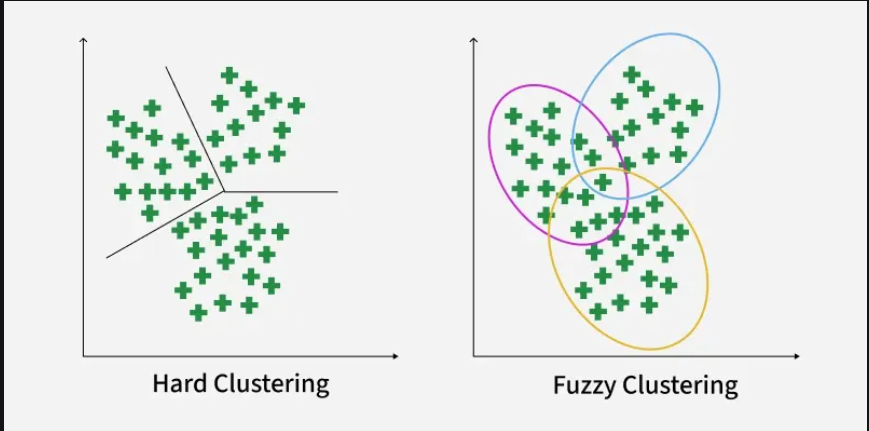

## Cara Kerja

Pengelompokan fuzzy menetapkan derajat keanggotaan untuk setiap titik data pada setiap klaster dan memperbarui nilai-nilai ini melalui proses iteratif.

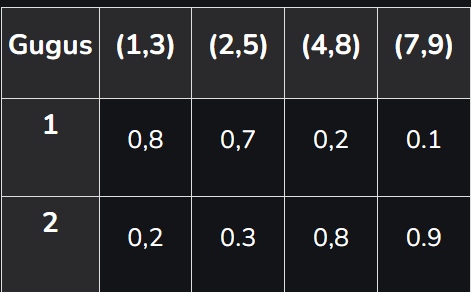

*Langkah 2 : Menghitung Sentroid Klaster* sentroid dihitung sebagai rata-rata tertimbang, di mana bobotnya adalah nilai keanggotaan yang dipangkatkan dengan parameter fuzzy m:

$V_{ij} = \frac{\sum_{k=1}^{n} \gamma_{ik}^{m} \cdot x_{kj}}{\sum_{k=1}^{n} \gamma_{ik}^{m}}$

$\gamma_{ik}=$ nilai keanggotaan titik k dalam kluster i $m =$ parameter fuzzy (biasanya bernilai 2) $x_{kj} =$ nilai atribut j untuk titik k

*Langkah 3: Hitung Jarak Antara Titik Data dan Sentroid* Hitung jarak Euclidean antara setiap titik dan setiap centroid untuk menentukan kedekatan, yang akan digunakan untuk memperbarui keanggotaan.

$D_{11} = \sqrt{(1 - 1.568)^2 + (3 - 4.051)^2} = 1.2$

$D_{12} = \sqrt{(1 - 5.35)^2 + (3 - 8.215)^2} = 6.79$

Jarak semua titik lainnya dihitung dari kedua titik pusat.

*Langkah 4: Perbarui Nilai Keanggotaan* Nilai keanggotaan diperbarui secara berbanding terbalik dengan jarak ini. Titik-titik yang lebih dekat ke centroid mendapatkan keanggotaan yang lebih tinggi.

Keanggotaan yang diperbarui $\gamma_{ik}$ untuk titik K di klaster i adalah:

$\gamma_{ik} = \left( \sum_{j=1}^{n} \left(\frac{d_{ki}^2}{d_{kj}^2} \right)^{\frac{1}{m-1}}\right)^{-1}$

*Langkah 5 :Ulangi hingga Konvergensi* Langkah 2–4 diulangi hingga nilai keanggotaan stabil, artinya tidak ada perubahan signifikan dari satu iterasi ke iterasi berikutnya. Ini menunjukkan bahwa pengelompokan telah mencapai keadaan optimal.

## Implementasi Fuzzy di R

### Package

```r
library(e1071)
```

### Menyiapkan Data

```r
set.seed(010)
data("USArrests")
data_fuzzy <- USArrests
```

### Eksplorasi Data

```r
head(data_fuzzy)
```

|  | Murder | Assault | UrbanPop | Rape |
| --- | --- | --- | --- | --- |
| Alabama | 13.2 | 236 | 58 | 21.2 |
| Alaska | 10.0 | 263 | 48 | 44.5 |
| Arizona | 8.1 | 294 | 80 | 31.0 |
| Arkansas | 8.8 | 190 | 50 | 19.5 |
| California | 9.0 | 276 | 91 | 40.6 |
| Colorado | 7.9 | 204 | 78 | 38.7 |

```r
summary(data_fuzzy)
```

```
##      Murder          Assault         UrbanPop          Rape
##  Min.   : 0.800   Min.   : 45.0   Min.   :32.00   Min.   : 7.30
##  1st Qu.: 4.075   1st Qu.:109.0   1st Qu.:54.50   1st Qu.:15.07
##  Median : 7.250   Median :159.0   Median :66.00   Median :20.10
##  Mean   : 7.788   Mean   :170.8   Mean   :65.54   Mean   :21.23
##  3rd Qu.:11.250   3rd Qu.:249.0   3rd Qu.:77.75   3rd Qu.:26.18
##  Max.   :17.400   Max.   :337.0   Max.   :91.00   Max.   :46.00
```

### Standarisasi Data

```r
data_scaled <- scale(data_fuzzy)
```

### Menjalankan Fuzzy C-Means

```r
fz_result <- cmeans(data_scaled, centers = 3, m = 2)
```

centers : jumlah klaster

m : parameter fuzzy

### Hasil

#### Pusat Klaster

```r
fz_result$centers
```

```
##       Murder    Assault   UrbanPop        Rape
## 1 -0.9585172 -1.0034724 -0.8486792 -0.94414196
## 2  0.9736668  1.0345320  0.3041592  0.85228723
## 3 -0.2806926 -0.2809903  0.3812735 -0.09372928
```

Nilai negatif = di bawah rata-rata

Nilai positif = di atas rata-rata

- **Cluster 1 (Low Crime Area)**

Semua variabel negatif besar

Murder, Assault, Rape → rendah UrbanPop → juga relatif rendah

-> wilayah dengan tingkat kriminalitas rendah (aman)

#### Derajat Keanggotaan

```r
head(fz_result$membership)
```

```
##                     1         2         3
## Alabama    0.11183157 0.6519512 0.2362172
## Alaska     0.16278652 0.5806565 0.2565570
## Arizona    0.07400993 0.7054473 0.2205428
## Arkansas   0.31225000 0.2672670 0.4204830
## California 0.11248856 0.6139111 0.2736004
## Colorado   0.10886224 0.5673510 0.3237868
```

Alabama: 0.11 (11%) ke Cluster 1

#### Klaster Dominan Tiap Data

```r
fz_result$cluster
```

```
##        Alabama         Alaska        Arizona       Arkansas     California
##              2              2              2              3              2
##       Colorado    Connecticut       Delaware        Florida        Georgia
##              2              3              3              2              2
##         Hawaii          Idaho       Illinois        Indiana           Iowa
##              3              1              2              3              1
##         Kansas       Kentucky      Louisiana          Maine       Maryland
##              3              1              2              1              2
##  Massachusetts       Michigan      Minnesota    Mississippi       Missouri
##              3              2              1              2              3
##        Montana       Nebraska         Nevada  New Hampshire     New Jersey
##              1              1              2              1              3
##     New Mexico       New York North Carolina   North Dakota           Ohio
##              2              2              2              1              3
##       Oklahoma         Oregon   Pennsylvania   Rhode Island South Carolina
##              3              3              3              3              2
##   South Dakota      Tennessee          Texas           Utah        Vermont
##              1              2              2              3              1
##       Virginia     Washington  West Virginia      Wisconsin        Wyoming
##              3              3              1              1              3
```

```r
hasil <- data.frame(
  State = rownames(data_fuzzy),
  Cluster = fz_result$cluster
)

head(hasil)
```

|  | State | Cluster |
| --- | --- | --- |
| Alabama | Alabama | 2 |
| Alaska | Alaska | 2 |
| Arizona | Arizona | 2 |
| Arkansas | Arkansas | 3 |
| California | California | 2 |
| Colorado | Colorado | 2 |

#### Visualisasi

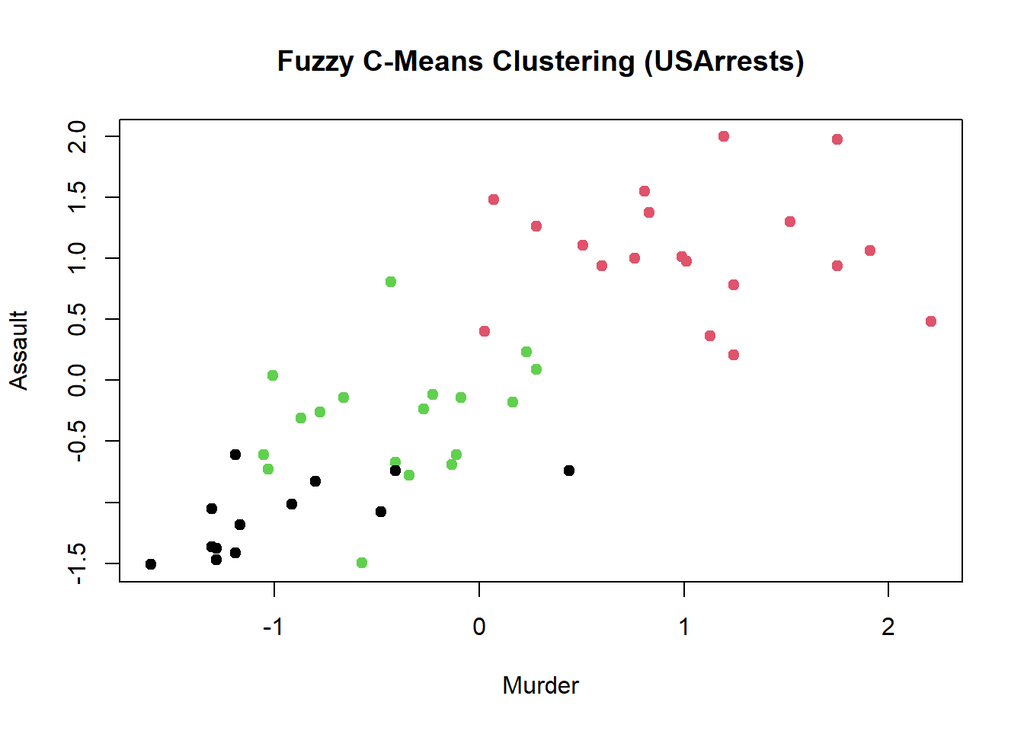

```r
plot(data_scaled[,1], data_scaled[,2],
     col = fz_result$cluster,
     pch = 19,
     xlab = "Murder", ylab = "Assault",
     main = "Fuzzy C-Means Clustering (USArrests)")
```